fossil

# GeCON co-expression networks, dug back up.

In 2014 Roy, Bhattacharyya and Kalita built co-expression networks from the angles between neighbouring expression values. Their Java program is gone. We rebuilt it from the equations and reran the paper. Of 34 results, 5 came back exactly, 14 agree, 4 partly agree and 8 differ; 2 were not attempted.

See every result

## Fig. 1

Fig. 1. Shifting and scaling patterns: three example genes in each panel.

Agrees

Published

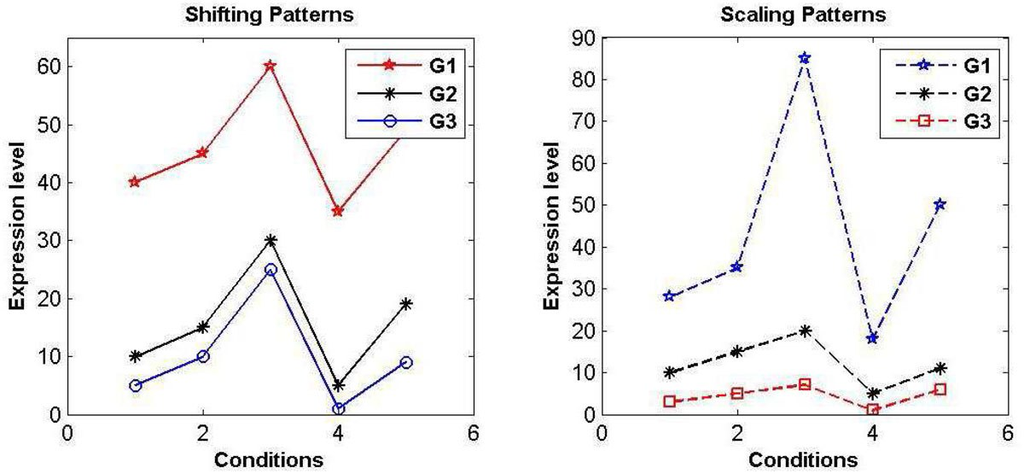

Our run

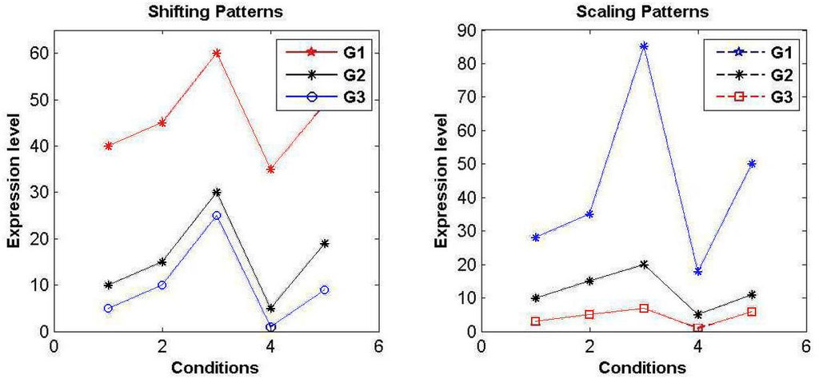

**Fig. 1, shifting patterns**

98.9% within 2 px, Agrees

**Fig. 1, scaling patterns**

95.3% within 2 px, Agrees

## Fig. 2

Fig. 2. Expression of the rat genes Mrps26 and Pfn2 over the 12 samples of GDS3702: inverted profiles.

Agrees

Published

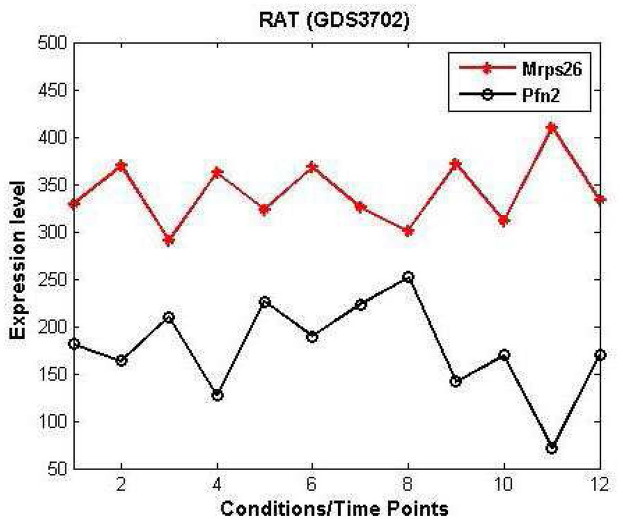

Our run

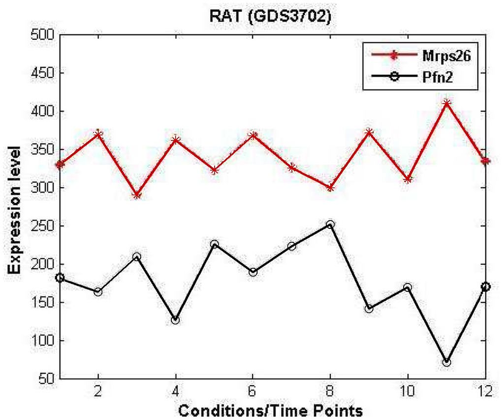

**Fig. 2, inverted profiles of Mrps26 and Pfn2 (GDS3702)**

92.9% within 2 px, Agrees

## Fig. 3

Fig. 3. Yeast genes YBL002W, YBL003C and YBL006W over 17 conditions: mixed regulation.

Agrees

Published

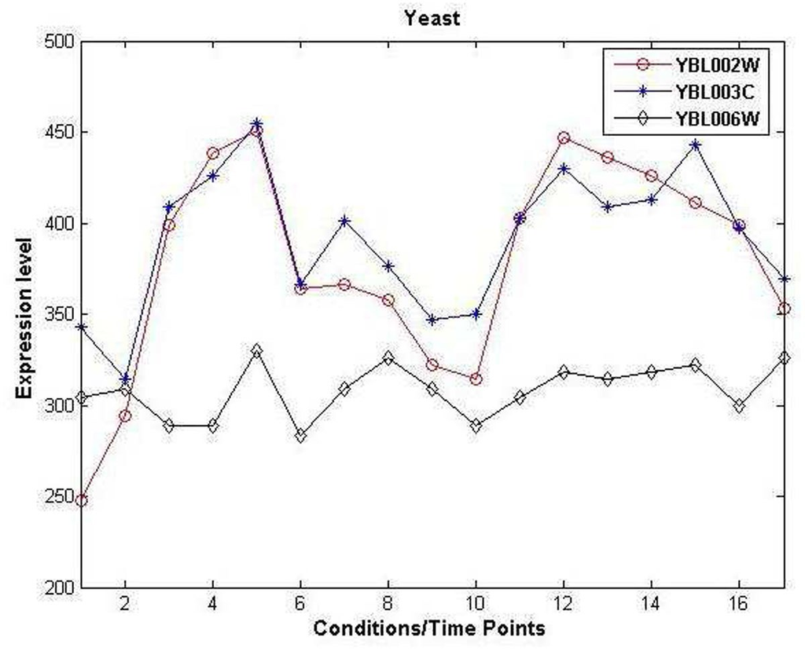

Our run

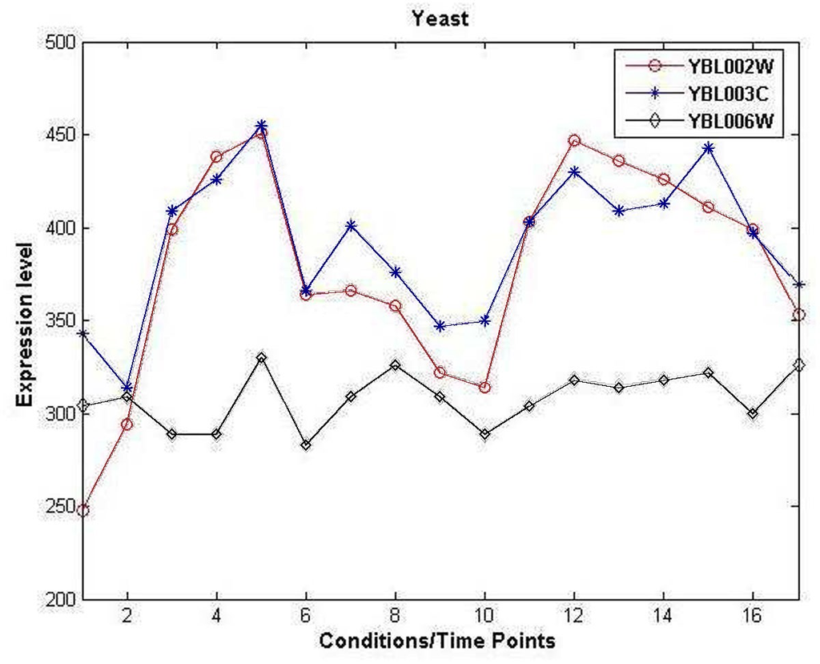

**Fig. 3, mixed patterns of YBL002W, YBL003C and YBL006W (yeast)**

96.3% within 2 px, Agrees

## Fig. 4

Fig. 4. AUPR, AUROC and F0.5 of GeCON, ARACNE, CLR and MRNET on the 13 in silico datasets of Table 1.

Agrees

Published

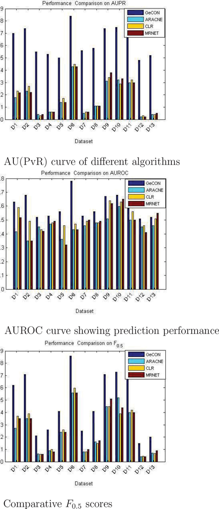

Our run

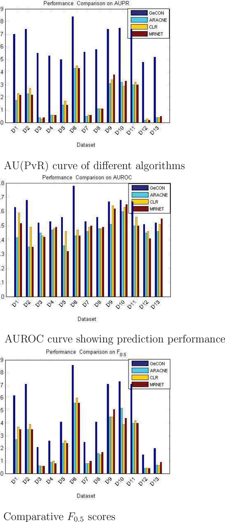

**Fig. 4a, AUPR bars against Table 2**

51 of 51 values, Agrees

**Fig. 4b, AUROC bars against Table 2**

50 of 51 values, Agrees

**Fig. 4c, F0.5 bars against Table 2**

51 of 51 values, Agrees

## Fig. 5

Fig. 5. CPU time of GeCON and ARACNE against the number of genes, 50 time points.

Agrees

Published

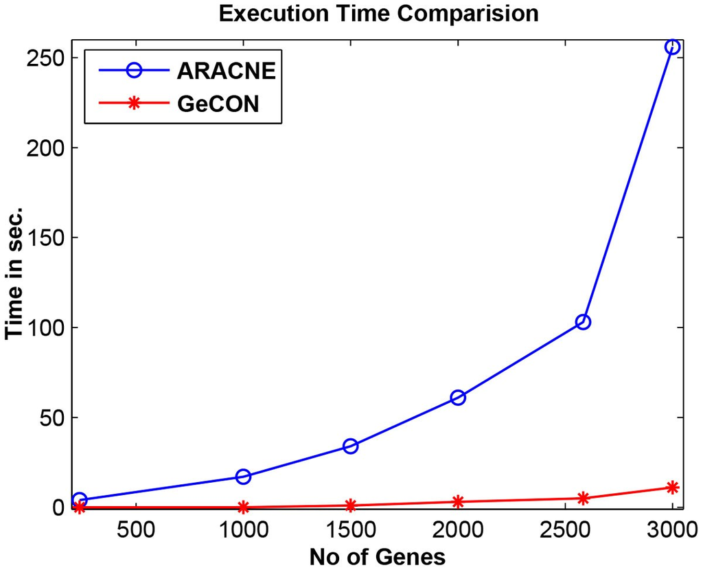

Our run

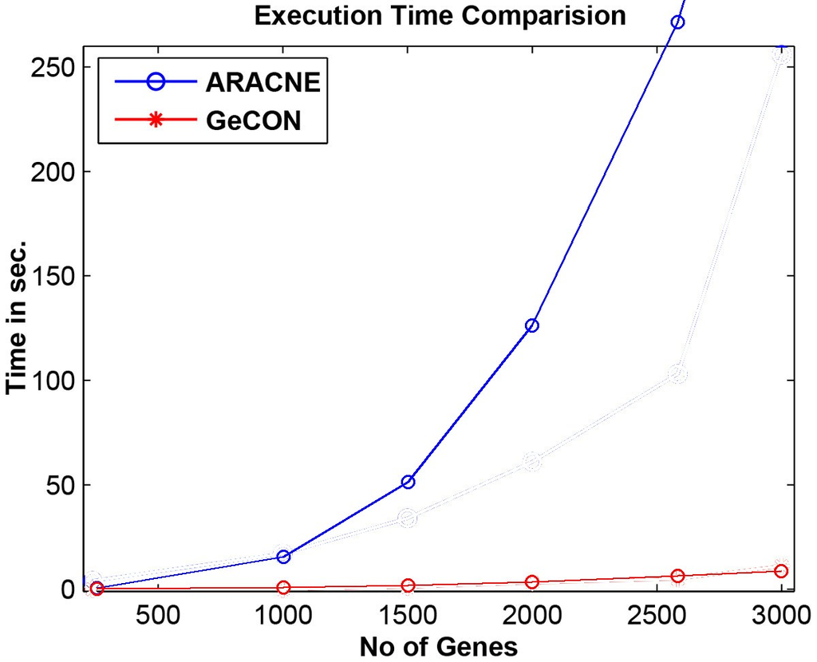

**Fig. 5, run time of GeCON and ARACNE**

6 of 6 values, Agrees

## Fig. 6

Fig. 6. Network, profile plot and heat map of one module from each real dataset. We redraw the profile plots of (a) to (c).

Inconclusive

Published

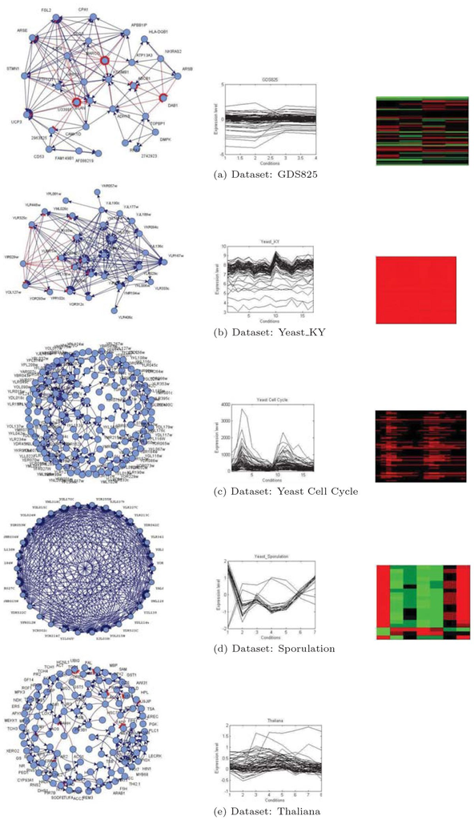

Our run

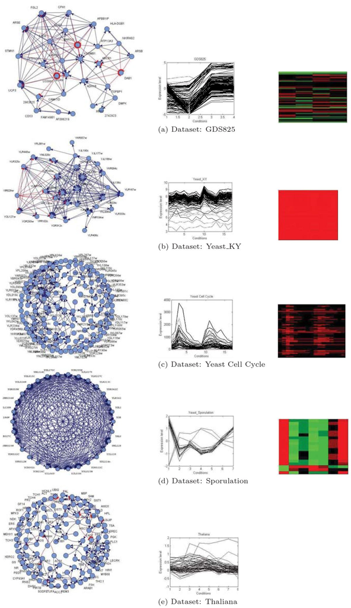

**Fig. 6a, GDS825 module profiles**

51.5% within 2 px, Inconclusive

**Fig. 6b, Yeast KY module profiles**

90.9% within 2 px, Agrees

**Fig. 6c, yeast cell cycle module profiles**

92.9% within 2 px, Partly agrees

GEO's GDS825 has 4 samples, not the paper's 8, and the 18 legible network genes span -0.6 to 2.0 where the panel's lines reach -4. Random gene sets score as well as any module, so the panel cannot identify its genes in the data we have. The panel is a dense tangle of lines in about 210 x 170 px; 35 random genes reach 82% to 90%, so a module scoring 93% is only a little better than chance. The network labels are not legible.

## Fig. 7

Fig. 7. The worked example: G = {343, 314, 409} becomes angles 138 and 52 with regulation -1 and +1.

Agrees

Published

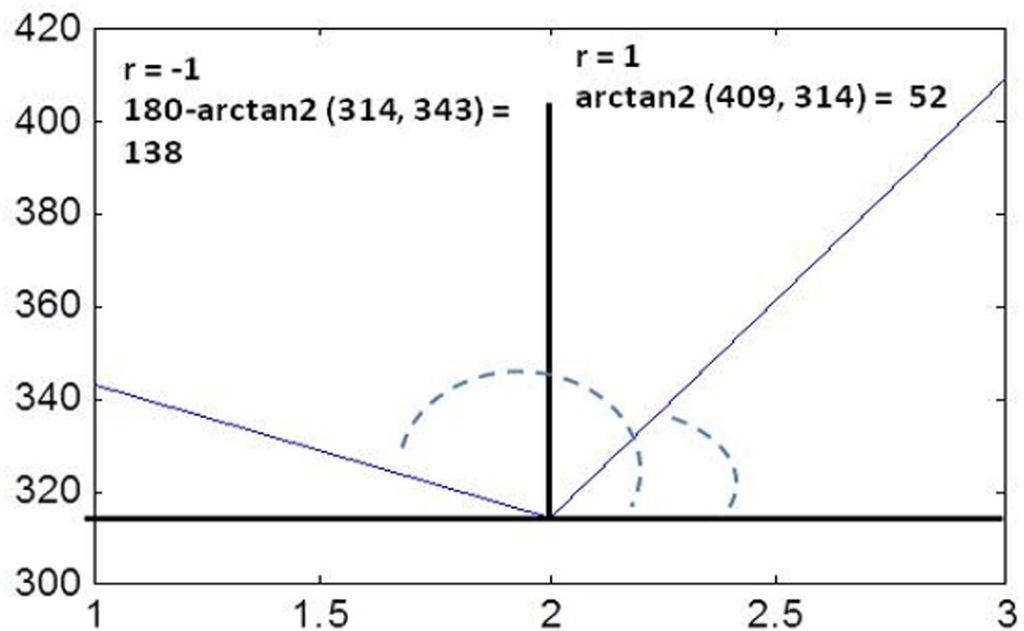

Our run

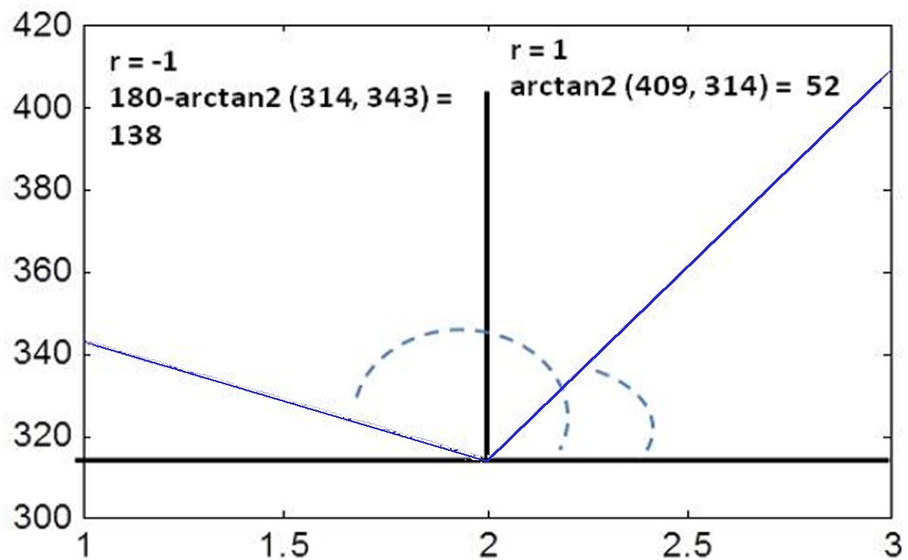

**Fig. 7, the worked example drawn**

95.4% within 2 px, Agrees

**Fig. 7 and Eq. (5): G = {343, 314, 409} becomes {138, -1; 52, 1}**

4 of 4 values, Exact

## Every result

Every figure, table and claim of the paper, with our value and the verdict computed from it.

Result

Verdict

Measure

Why

Fig. 1, shifting patterns

Agrees

98.9% within 2 px

Fig. 1, scaling patterns

Agrees

95.3% within 2 px

GeCON captures shifting and scaling patterns (Fig. 1 and the Fig. 6 discussion)

Partly agrees

1 of 2 values

- GeCON connects all three shifting genes positively (theta 0.5, tau 20): paper yes, ours **no**
- GeCON connects all three scaling genes positively (theta 0.5, tau 20): paper yes, ours **yes**

On Fig. 1's own shifting example GeCON at theta 0.5 does not connect G1 with G2 or G3: two of their four edges match (support exactly 0.5, not above theta). The scaling example is connected throughout.

Fig. 2, inverted profiles of Mrps26 and Pfn2 (GDS3702)

Agrees

92.9% within 2 px

Fig. 3, mixed patterns of YBL002W, YBL003C and YBL006W (yeast)

Agrees

96.3% within 2 px

Fig. 4a, AUPR bars against Table 2

Agrees

51 of 51 values

- D1 gecon: paper 0.7, ours **0.701**
- D1 aracne: paper 0.177, ours **0.181**
- D1 clr: paper 0.23, ours **0.234**
- D1 mrnet: paper 0.218, ours **0.219**
- D2 gecon: paper 0.74, ours **0.741**
- D2 aracne: paper 0.229, ours **0.233**
- D2 clr: paper 0.27, ours **0.273**
- D2 mrnet: paper 0.22, ours **0.222**
- D3 gecon: paper 0.55, ours **0.551**
- D3 aracne: paper 0.04, ours **0.043**
- D3 clr: paper 0.03, ours **0.034**
- D3 mrnet: paper 0.04, ours **0.043**
- D4 gecon: paper 0.53, ours **0.532**
- D4 aracne: paper 0.06, ours **0.062**
- D4 clr: paper 0.06, ours **0.062**
- D4 mrnet: paper 0.06, ours **0.062**
- D5 gecon: paper 0.5, ours **0.502**
- D5 aracne: paper 0.14, ours **0.141**
- D5 clr: paper 0.17, ours **0.173**
- D5 mrnet: paper 0.14, ours **0.141**
- D6 gecon: paper 0.84, ours **0.842**
- D6 aracne: paper 0.43, ours **0.431**
- D6 clr: paper 0.45, ours **0.451**
- D6 mrnet: paper 0.43, ours **0.431**
- D7 gecon: paper 0.56, ours **0.56**
- D7 aracne: paper 0.05, ours **0.053**
- D7 clr: paper 0.06, ours **0.065**
- D7 mrnet: paper 0.06, ours **0.062**
- D8 gecon: paper 0.58, ours **0.581**
- D8 aracne: paper 0.11, ours **0.111**
- D8 clr: paper 0.11, ours **0.112**
- D8 mrnet: paper 0.11, ours **0.111**
- D9 gecon: paper 0.74, ours **0.74**
- D9 aracne: paper 0.31, ours **0.316**
- D9 clr: paper 0.34, ours **0.345**
- D9 mrnet: paper 0.38, ours **0.382**
- D10 gecon: paper 0.75, ours **0.75**
- D10 aracne: paper 0.32, ours **0.323**
- D10 clr: paper 0.29, ours **0.293**
- D10 mrnet: paper 0.33, ours **0.333**
- D11 aracne: paper 0.3, ours **0.301**
- D11 clr: paper 0.32, ours **0.326**
- D11 mrnet: paper 0.3, ours **0.301**
- D12 gecon: paper 0.48, ours **0.483**
- D12 aracne: paper 0.02, ours **0.023**
- D12 clr: paper 0.03, ours **0.034**
- D12 mrnet: paper 0.02, ours **0.023**
- D13 gecon: paper 0.52, ours **0.522**
- D13 aracne: paper 0.04, ours **0.043**
- D13 clr: paper 0.04, ours **0.043**
- D13 mrnet: paper 0.05, ours **0.053**

Fig. 4b, AUROC bars against Table 2

Agrees

50 of 51 values

- D1 gecon: paper 0.63, ours **0.633**
- D1 aracne: paper 0.416, ours **0.419**
- D1 clr: paper 0.59, ours **0.592**
- D1 mrnet: paper 0.517, ours **0.519**
- D2 gecon: paper 0.68, ours **0.682**
- D2 aracne: paper 0.35, ours **0.352**
- D2 clr: paper 0.49, ours **0.494**
- D2 mrnet: paper 0.35, ours **0.352**
- D3 gecon: paper 0.52, ours **0.525**
- D3 aracne: paper 0.45, ours **0.453**
- D3 clr: paper 0.43, ours **0.434**
- D3 mrnet: paper 0.42, ours **0.422**
- D4 gecon: paper 0.53, ours **0.531**
- D4 aracne: paper 0.47, ours **0.473**
- D4 clr: paper 0.48, ours **0.482**
- D4 mrnet: paper 0.49, ours **0.493**
- D5 gecon: paper 0.56, ours **0.563**
- D5 aracne: paper 0.36, ours **0.364**
- D5 clr: paper 0.46, ours **0.463**
- D5 mrnet: paper 0.32, ours **0.323**
- D6 gecon: paper 0.78, ours **0.783**
- D6 aracne: paper 0.43, ours **0.434**
- D6 clr: paper 0.47, ours **0.473**
- D6 mrnet: paper 0.43, ours **0.434**
- D7 gecon: paper 0.53, ours **0.531**
- D7 aracne: paper 0.46, ours **0.461**
- D7 clr: paper 0.49, ours **0.494**
- D7 mrnet: paper 0.5, ours **0.502**
- D8 gecon: paper 0.56, ours **0.563**
- D8 aracne: paper 0.48, ours **0.482**
- D8 clr: paper 0.48, ours **0.482**
- D8 mrnet: paper 0.49, ours **0.494**
- D9 gecon: paper 0.67, ours **0.674**
- D9 aracne: paper 0.51, ours **0.512**
- D9 clr: paper 0.64, ours **0.642**
- D9 mrnet: paper 0.62, ours **0.621**
- D10 gecon: paper 0.68, ours **0.682**
- D10 aracne: paper 0.6, ours **0.601**
- D10 clr: paper 0.63, ours **0.633**
- D10 mrnet: paper 0.65, ours **0.653**
- D11 aracne: paper 0.5, ours **0.502**
- D11 clr: paper 0.56, ours **0.563**
- D11 mrnet: paper 0.5, ours **0.502**
- D12 gecon: paper 0.51, ours **0.512**
- D12 aracne: paper 0.45, ours **0.452**
- D12 clr: paper 0.46, ours **0.463**
- D12 mrnet: paper 0.41, ours **0.413**
- D13 gecon: paper 0.52, ours **0.522**
- D13 aracne: paper 0.46, ours **0.463**
- D13 clr: paper 0.51, ours **0.533**
- D13 mrnet: paper 0.55, ours **0.551**

Fig. 4c, F0.5 bars against Table 2

Agrees

51 of 51 values

- D1 gecon: paper 0.62, ours **0.622**
- D1 aracne: paper 0.271, ours **0.276**
- D1 clr: paper 0.37, ours **0.365**
- D1 mrnet: paper 0.35, ours **0.352**
- D2 gecon: paper 0.71, ours **0.711**
- D2 aracne: paper 0.35, ours **0.352**
- D2 clr: paper 0.39, ours **0.399**
- D2 mrnet: paper 0.35, ours **0.352**
- D3 gecon: paper 0.21, ours **0.213**
- D3 aracne: paper 0.063, ours **0.066**
- D3 clr: paper 0.06, ours **0.062**
- D3 mrnet: paper 0.06, ours **0.062**
- D4 gecon: paper 0.26, ours **0.26**
- D4 aracne: paper 0.09, ours **0.093**
- D4 clr: paper 0.1, ours **0.103**
- D4 mrnet: paper 0.08, ours **0.082**
- D5 gecon: paper 0.41, ours **0.411**
- D5 aracne: paper 0.24, ours **0.241**
- D5 clr: paper 0.26, ours **0.26**
- D5 mrnet: paper 0.24, ours **0.241**
- D6 gecon: paper 0.86, ours **0.86**
- D6 aracne: paper 0.56, ours **0.561**
- D6 clr: paper 0.6, ours **0.604**
- D6 mrnet: paper 0.56, ours **0.561**
- D7 gecon: paper 0.25, ours **0.251**
- D7 aracne: paper 0.08, ours **0.082**
- D7 clr: paper 0.08, ours **0.085**
- D7 mrnet: paper 0.1, ours **0.102**
- D8 gecon: paper 0.41, ours **0.41**
- D8 aracne: paper 0.16, ours **0.162**
- D8 clr: paper 0.15, ours **0.155**
- D8 mrnet: paper 0.17, ours **0.173**
- D9 gecon: paper 0.71, ours **0.711**
- D9 aracne: paper 0.45, ours **0.45**
- D9 clr: paper 0.45, ours **0.45**
- D9 mrnet: paper 0.51, ours **0.512**
- D10 gecon: paper 0.73, ours **0.73**
- D10 aracne: paper 0.52, ours **0.521**
- D10 clr: paper 0.39, ours **0.397**
- D10 mrnet: paper 0.44, ours **0.439**
- D11 aracne: paper 0.4, ours **0.402**
- D11 clr: paper 0.42, ours **0.42**
- D11 mrnet: paper 0.4, ours **0.401**
- D12 gecon: paper 0.15, ours **0.15**
- D12 aracne: paper 0.042, ours **0.042**
- D12 clr: paper 0.044, ours **0.051**
- D12 mrnet: paper 0.041, ours **0.042**
- D13 gecon: paper 0.2, ours **0.202**
- D13 aracne: paper 0.069, ours **0.072**
- D13 clr: paper 0.066, ours **0.07**
- D13 mrnet: paper 0.09, ours **0.091**

Fig. 5, run time of GeCON and ARACNE

Agrees

6 of 6 values

- faster at 250 genes: paper yes, ours **yes**
- faster at 1000 genes: paper yes, ours **yes**
- faster at 1500 genes: paper yes, ours **yes**
- faster at 2000 genes: paper yes, ours **yes**
- faster at 2585 genes: paper yes, ours **yes**
- faster at 3000 genes: paper yes, ours **yes**

Fig. 6a, GDS825 module profiles

Inconclusive

51.5% within 2 px

GEO's GDS825 has 4 samples, not the paper's 8, and the 18 legible network genes span -0.6 to 2.0 where the panel's lines reach -4. Random gene sets score as well as any module, so the panel cannot identify its genes in the data we have.

Fig. 6b, Yeast KY module profiles

Agrees

90.9% within 2 px

Fig. 6c, yeast cell cycle module profiles

Partly agrees

92.9% within 2 px

The panel is a dense tangle of lines in about 210 x 170 px; 35 random genes reach 82% to 90%, so a module scoring 93% is only a little better than chance. The network labels are not legible.

Fig. 6d, sporulation module

Not attempted

The sporulation file failed TLS verification from our runner and no archive was reachable.

Fig. 6e, Arabidopsis module

Not attempted

The 517 x 13 Arabidopsis matrix was not found; the cited page holds a 138 x 8 example only.

Fig. 7, the worked example drawn

Agrees

95.4% within 2 px

Fig. 7 and Eq. (5): G = {343, 314, 409} becomes {138, -1; 52, 1}

Exact

4 of 4 values

- angle, edge 1: paper 138, ours **137.5274**
- angle, edge 2: paper 52, ours **52.4856**
- regulation, edge 1: paper -1, ours **-1**
- regulation, edge 2: paper 1, ours **1**

Table 1, the 13 in silico networks and their sizes

Exact

13 of 13 values

- D1 Ecoli1 size: paper 10, ours **10**
- D2 Ecoli2 size: paper 10, ours **10**
- D3 Ecoli1 size: paper 50, ours **50**
- D4 Ecoli2 size: paper 50, ours **50**
- D5 Yeast1 size: paper 10, ours **10**
- D6 Yeast2 size: paper 10, ours **10**
- D7 Yeast1 size: paper 50, ours **50**
- D8 Yeast2 size: paper 50, ours **50**
- D9 insilico1 size: paper 10, ours **10**
- D10 insilico2 size: paper 10, ours **10**
- D11 insilico3 size: paper 10, ours **10**
- D12 insilico1 size: paper 100, ours **100**
- D13 insilico2 size: paper 100, ours **100**

Table 2, AUPR of GeCON, ARACNE, CLR and MRNET on D1 to D13

Differs

0 of 52 values

- D1 GeCON: paper 0.7, ours **0.243**
- D1 ARACNE: paper 0.177, ours **0.2285**
- D1 CLR: paper 0.23, ours **0.2745**
- D1 MRNET: paper 0.218, ours **0.2245**
- D2 GeCON: paper 0.74, ours **0.4662**
- D2 ARACNE: paper 0.229, ours **0.2474**
- D2 CLR: paper 0.27, ours **0.2792**
- D2 MRNET: paper 0.22, ours **0.2975**
- D3 GeCON: paper 0.55, ours **0.0403**
- D3 ARACNE: paper 0.04, ours **0.0672**
- D3 CLR: paper 0.03, ours **0.0914**
- D3 MRNET: paper 0.04, ours **0.0883**
- D4 GeCON: paper 0.53, ours **0.0737**
- D4 ARACNE: paper 0.06, ours **0.1241**
- D4 CLR: paper 0.06, ours **0.1292**
- D4 MRNET: paper 0.06, ours **0.1399**
- D5 GeCON: paper 0.5, ours **0.1412**
- D5 ARACNE: paper 0.14, ours **0.2129**
- D5 CLR: paper 0.17, ours **0.2461**
- D5 MRNET: paper 0.14, ours **0.2577**
- D6 GeCON: paper 0.84, ours **0.5254**
- D6 ARACNE: paper 0.43, ours **0.7076**
- D6 CLR: paper 0.45, ours **0.7413**
- D6 MRNET: paper 0.43, ours **0.6525**
- D7 GeCON: paper 0.56, ours **0.0933**
- D7 ARACNE: paper 0.05, ours **0.2187**
- D7 CLR: paper 0.06, ours **0.1958**
- D7 MRNET: paper 0.06, ours **0.2163**
- D8 GeCON: paper 0.58, ours **0.139**
- D8 ARACNE: paper 0.11, ours **0.1991**
- D8 CLR: paper 0.11, ours **0.2056**
- D8 MRNET: paper 0.11, ours **0.1885**
- D9 GeCON: paper 0.74, ours **0.3297**
- D9 ARACNE: paper 0.31, ours **0.5163**
- D9 CLR: paper 0.34, ours **0.5361**
- D9 MRNET: paper 0.38, ours **0.5295**
- D10 GeCON: paper 0.75, ours **0.1948**
- D10 ARACNE: paper 0.32, ours **0.3264**
- D10 CLR: paper 0.29, ours **0.3869**
- D10 MRNET: paper 0.33, ours **0.3703**
- D11 GeCON: paper 0.74, ours **0.3054**
- D11 ARACNE: paper 0.3, ours **0.5214**
- D11 CLR: paper 0.32, ours **0.4911**
- D11 MRNET: paper 0.3, ours **0.4976**
- D12 GeCON: paper 0.48, ours **0.0423**
- D12 ARACNE: paper 0.02, ours **0.088**
- D12 CLR: paper 0.03, ours **0.0921**
- D12 MRNET: paper 0.02, ours **0.0856**
- D13 GeCON: paper 0.52, ours **0.0424**
- D13 ARACNE: paper 0.04, ours **0.12**
- D13 CLR: paper 0.04, ours **0.1114**
- D13 MRNET: paper 0.05, ours **0.1154**

GeCON as the paper describes it ranks pairs no better than chance on these data (mean AUPR 0.203, the share of true pairs is 0.203; mean AUROC 0.485), while minet's methods reach AUPR 0.275 to 0.291 and AUROC 0.535 to 0.61. At theta 0.5 and tau 20 it connects 84% to 100% of all pairs, because on positive values almost every edge angle of Eq. (5) sits near 45 or 135 degrees. No variant we tried brings GeCON's mean scores near the paper's (best mean AUPR 0.255 against 0.633); the few single cells that fall within printed precision are not counted as agreement. The comparators' values differ too, so the authors' simulations and scoring cannot be recovered. The paper's GeCON columns follow each network's share of true pairs p: a network that connects every pair, scored as one precision-recall point with a straight line from (0, 1), gets (1 + p) / 2, and the paper's GeCON AUROC averages 0.603 against 0.601 for that formula (r 0.97, 12 of 13 datasets within 0.05). This suggests the paper scored a nearly complete network in a way that rewards density, but it matches only 5 of 13 values at printed precision, so it stays a hypothesis.

Table 2, AUROC

Partly agrees

1 of 52 values

- D1 GeCON: paper 0.63, ours **0.5348**
- D1 ARACNE: paper 0.416, ours **0.4893**
- D1 CLR: paper 0.59, ours **0.5735**
- D1 MRNET: paper 0.517, ours **0.4706**
- D2 GeCON: paper 0.68, ours **0.6644**
- D2 ARACNE: paper 0.35, ours **0.4189**
- D2 CLR: paper 0.49, ours **0.4356**
- D2 MRNET: paper 0.35, ours **0.4711**
- D3 GeCON: paper 0.52, ours **0.4085**
- D3 ARACNE: paper 0.45, ours **0.5194**
- D3 CLR: paper 0.43, ours **0.6342**
- D3 MRNET: paper 0.42, ours **0.6201**
- D4 GeCON: paper 0.53, ours **0.528**
- D4 ARACNE: paper 0.47, ours **0.5414**
- D4 CLR: paper 0.48, ours **0.6321**
- D4 MRNET: paper 0.49, ours **0.6361**
- D5 GeCON: paper 0.56, ours **0.2271**
- D5 ARACNE: paper 0.36, ours **0.4971**
- D5 CLR: paper 0.46, ours **0.5814**
- D5 MRNET: paper 0.32, ours **0.5771**
- D6 GeCON: paper 0.78, ours **0.505**
- D6 ARACNE: paper 0.43, ours **0.606**
- D6 CLR: paper 0.47, ours **0.7**
- D6 MRNET: paper 0.43, ours **0.602**
- D7 GeCON: paper 0.53, ours **0.6131**
- D7 ARACNE: paper 0.46, ours **0.6029**
- D7 CLR: paper 0.49, ours **0.6761**
- D7 MRNET: paper 0.5, ours **0.6741**
- D8 GeCON: paper 0.56, ours **0.5007**
- D8 ARACNE: paper 0.48, ours **0.5375**
- D8 CLR: paper 0.48, ours **0.5609**
- D8 MRNET: paper 0.49, ours **0.5621**
- D9 GeCON: paper 0.67, ours **0.5589**
- D9 ARACNE: paper 0.51, ours **0.5757**
- D9 CLR: paper 0.64, ours **0.613**
- D9 MRNET: paper 0.62, ours **0.6118**
- D10 GeCON: paper 0.68, ours **0.2639**
- D10 ARACNE: paper 0.6, ours **0.4886**
- D10 CLR: paper 0.63, ours **0.5758**
- D10 MRNET: paper 0.65, ours **0.5783**
- D11 GeCON: paper 0.67, ours **0.4811**
- D11 ARACNE: paper 0.5, ours **0.5778**
- D11 CLR: paper 0.56, ours **0.62**
- D11 MRNET: paper 0.5, ours **0.5533**
- D12 GeCON: paper 0.51, ours **0.5563**
- D12 ARACNE: paper 0.45, ours **0.5549**
- D12 CLR: paper 0.46, ours **0.7009**
- D12 MRNET: paper 0.41, ours **0.6819**
- D13 GeCON: paper 0.52, ours **0.4577**
- D13 ARACNE: paper 0.46, ours **0.5398**
- D13 CLR: paper 0.51, ours **0.6317**
- D13 MRNET: paper 0.55, ours **0.6347**

GeCON as the paper describes it ranks pairs no better than chance on these data (mean AUPR 0.203, the share of true pairs is 0.203; mean AUROC 0.485), while minet's methods reach AUPR 0.275 to 0.291 and AUROC 0.535 to 0.61. At theta 0.5 and tau 20 it connects 84% to 100% of all pairs, because on positive values almost every edge angle of Eq. (5) sits near 45 or 135 degrees. No variant we tried brings GeCON's mean scores near the paper's (best mean AUPR 0.255 against 0.633); the few single cells that fall within printed precision are not counted as agreement. The comparators' values differ too, so the authors' simulations and scoring cannot be recovered. The paper's GeCON columns follow each network's share of true pairs p: a network that connects every pair, scored as one precision-recall point with a straight line from (0, 1), gets (1 + p) / 2, and the paper's GeCON AUROC averages 0.603 against 0.601 for that formula (r 0.97, 12 of 13 datasets within 0.05). This suggests the paper scored a nearly complete network in a way that rewards density, but it matches only 5 of 13 values at printed precision, so it stays a hypothesis.

Table 2, F0.5

Differs

0 of 52 values

- D1 GeCON: paper 0.62, ours **0.3659**
- D1 ARACNE: paper 0.271, ours **0.3191**
- D1 CLR: paper 0.37, ours **0.4**
- D1 MRNET: paper 0.35, ours **0.3636**
- D2 GeCON: paper 0.71, ours **0.5495**
- D2 ARACNE: paper 0.35, ours **0.3846**
- D2 CLR: paper 0.39, ours **0.3846**
- D2 MRNET: paper 0.35, ours **0.404**
- D3 GeCON: paper 0.21, ours **0.0625**
- D3 ARACNE: paper 0.063, ours **0.1068**
- D3 CLR: paper 0.06, ours **0.1437**
- D3 MRNET: paper 0.06, ours **0.1592**
- D4 GeCON: paper 0.26, ours **0.101**
- D4 ARACNE: paper 0.09, ours **0.2655**
- D4 CLR: paper 0.1, ours **0.2055**
- D4 MRNET: paper 0.08, ours **0.2609**
- D5 GeCON: paper 0.41, ours **0.2632**
- D5 ARACNE: paper 0.24, ours **0.2632**
- D5 CLR: paper 0.26, ours **0.3788**
- D5 MRNET: paper 0.24, ours **0.3788**
- D6 GeCON: paper 0.86, ours **0.6536**
- D6 ARACNE: paper 0.56, ours **0.6154**
- D6 CLR: paper 0.6, ours **0.7216**
- D6 MRNET: paper 0.56, ours **0.6436**
- D7 GeCON: paper 0.25, ours **0.1434**
- D7 ARACNE: paper 0.08, ours **0.3468**
- D7 CLR: paper 0.08, ours **0.3346**
- D7 MRNET: paper 0.1, ours **0.3595**
- D8 GeCON: paper 0.41, ours **0.1786**
- D8 ARACNE: paper 0.16, ours **0.2183**
- D8 CLR: paper 0.15, ours **0.282**
- D8 MRNET: paper 0.17, ours **0.2612**
- D9 GeCON: paper 0.71, ours **0.4386**
- D9 ARACNE: paper 0.45, ours **0.6061**
- D9 CLR: paper 0.45, ours **0.6061**
- D9 MRNET: paper 0.51, ours **0.6061**
- D10 GeCON: paper 0.73, ours **0.3125**
- D10 ARACNE: paper 0.52, ours **0.3571**
- D10 CLR: paper 0.39, ours **0.4688**
- D10 MRNET: paper 0.44, ours **0.3947**
- D11 GeCON: paper 0.71, ours **0.3937**
- D11 ARACNE: paper 0.4, ours **0.5556**
- D11 CLR: paper 0.42, ours **0.4945**
- D11 MRNET: paper 0.4, ours **0.5556**
- D12 GeCON: paper 0.15, ours **0.0613**
- D12 ARACNE: paper 0.042, ours **0.1336**
- D12 CLR: paper 0.044, ours **0.1572**
- D12 MRNET: paper 0.041, ours **0.1434**
- D13 GeCON: paper 0.2, ours **0.0614**
- D13 ARACNE: paper 0.069, ours **0.1618**
- D13 CLR: paper 0.066, ours **0.1661**
- D13 MRNET: paper 0.09, ours **0.172**

GeCON as the paper describes it ranks pairs no better than chance on these data (mean AUPR 0.203, the share of true pairs is 0.203; mean AUROC 0.485), while minet's methods reach AUPR 0.275 to 0.291 and AUROC 0.535 to 0.61. At theta 0.5 and tau 20 it connects 84% to 100% of all pairs, because on positive values almost every edge angle of Eq. (5) sits near 45 or 135 degrees. No variant we tried brings GeCON's mean scores near the paper's (best mean AUPR 0.255 against 0.633); the few single cells that fall within printed precision are not counted as agreement. The comparators' values differ too, so the authors' simulations and scoring cannot be recovered. The paper's GeCON columns follow each network's share of true pairs p: a network that connects every pair, scored as one precision-recall point with a straight line from (0, 1), gets (1 + p) / 2, and the paper's GeCON AUROC averages 0.603 against 0.601 for that formula (r 0.97, 12 of 13 datasets within 0.05). This suggests the paper scored a nearly complete network in a way that rewards density, but it matches only 5 of 13 values at printed precision, so it stays a hypothesis.

Table 3, gene and sample counts of the real datasets

Agrees

4 of 7 values

- Yeast KY genes: paper 237, ours **237**
- Yeast KY samples: paper 18, ours **17**
- Yeast cell cycle genes: paper 384, ours **384**
- Yeast cell cycle samples: paper 18, ours **17**
- GDS825 samples: paper 8, ours **4**
- GDS958 (Subset) samples: paper 12, ours **12**
- GDS3702 (Subset) samples: paper 12, ours **12**

The public files have 17 conditions for Yeast KY and the cell cycle set, not 18, and GEO's GDS825 has 4 samples, not 8. The sporulation file (TLS failure from our runner, no reachable archive) and the 517-gene Arabidopsis matrix could not be obtained, so they have no field. The subset sizes of GDS958 and GDS3702 are our filter's.

Table 4, GO terms of selected modules (GeneMANIA)

Differs

4 of 10 values

- Yeast KY module 1: cytosolic ribosome: paper yes, ours **yes**
- Yeast KY module 2: structural constituent of ribosome: paper yes, ours **yes**
- Yeast KY module 3: DNA-dependent DNA replication: paper yes, ours **yes**
- GDS3702 module 1: mitochondrial inner membrane: paper yes, ours **no**
- GDS3702 module 2: oxidoreductase activity: paper yes, ours **no**
- GDS3702 module 3: aging regulation of: paper yes, ours **no**
- GDS3702 module 4: lipid catabolic process: paper yes, ours **yes**
- GDS3702 module 5: iron-sulfur cluster binding: paper yes, ours **no**
- GDS958 module 1: vacuolar proton-transporting V-type ATPase complex: paper yes, ours **no**
- GDS958 module 2: cell cortex: paper yes, ours **no**

Terms not found in our modules: GeneMANIA's and FuncAssociate's 2014 annotations and the authors' modules are gone, and our module cut and filters are guesses. Rows of Sporulation, Thaliana are left out: the sporulation file failed TLS verification from our runner and no archive was reachable, and the 517 x 13 Arabidopsis matrix was not located.

Table 5, GO terms of selected modules (FuncAssociate)

Differs

3 of 7 values

- Yeast KY module 1: cytosolic ribosome: paper yes, ours **yes**
- Yeast KY module 2: DNA replication: paper yes, ours **yes**
- GDS3702 module 1: response to neutrient: paper yes, ours **yes**
- GDS3702 module 2: hydrolase activity: paper yes, ours **no**
- GDS3702 module 3: protein complex: paper yes, ours **no**
- GDS958 module 1: intracellular part: paper yes, ours **no**
- GDS958 module 2: intracellular membrane-bounded organelle: paper yes, ours **no**

Terms not found in our modules: GeneMANIA's and FuncAssociate's 2014 annotations and the authors' modules are gone, and our module cut and filters are guesses. Rows of GDS825, Sporulation are left out: GEO's GDS825 has 4 samples, not the paper's 8, and the sporulation file could not be fetched.

Claims recomputed from the paper's own Table 2

Agrees

"GeCON outperforms all other algorithms ... on all three scores" (Fig. 4, Table 2)

Differs

0 of 3 values

- GeCON best on every dataset, AUPR: paper yes, ours **no**
- GeCON best on every dataset, AUROC: paper yes, ours **no**
- GeCON best on every dataset, F: paper yes, ours **no**

GeCON as the paper describes it ranks pairs no better than chance on these data (mean AUPR 0.203, the share of true pairs is 0.203; mean AUROC 0.485), while minet's methods reach AUPR 0.275 to 0.291 and AUROC 0.535 to 0.61. At theta 0.5 and tau 20 it connects 84% to 100% of all pairs, because on positive values almost every edge angle of Eq. (5) sits near 45 or 135 degrees. No variant we tried brings GeCON's mean scores near the paper's (best mean AUPR 0.255 against 0.633); the few single cells that fall within printed precision are not counted as agreement. The comparators' values differ too, so the authors' simulations and scoring cannot be recovered. The paper's GeCON columns follow each network's share of true pairs p: a network that connects every pair, scored as one precision-recall point with a straight line from (0, 1), gets (1 + p) / 2, and the paper's GeCON AUROC averages 0.603 against 0.601 for that formula (r 0.97, 12 of 13 datasets within 0.05). This suggests the paper scored a nearly complete network in a way that rewards density, but it matches only 5 of 13 values at printed precision, so it stays a hypothesis.

Average improvement of GeCON over ARACNE, CLR and MRNET (Table 2, last row)

Differs

0 of 9 values

- AUPR over ARACNE (%): paper 269.72, ours **-26.31**
- AUPR over CLR (%): paper 242.91, ours **-30.26**
- AUPR over MRNET (%): paper 249.024, ours **-28.03**
- AUROC over ARACNE (%): paper 32.07, ours **-9.35**
- AUROC over CLR (%): paper 17.18, ours **-20.61**
- AUROC over MRNET (%): paper 25.50, ours **-17.91**
- F over ARACNE (%): paper 89.07, ours **-17.28**
- F over CLR (%): paper 84.31, ours **-24.42**
- F over MRNET (%): paper 83.72, ours **-23.75**

GeCON as the paper describes it ranks pairs no better than chance on these data (mean AUPR 0.203, the share of true pairs is 0.203; mean AUROC 0.485), while minet's methods reach AUPR 0.275 to 0.291 and AUROC 0.535 to 0.61. At theta 0.5 and tau 20 it connects 84% to 100% of all pairs, because on positive values almost every edge angle of Eq. (5) sits near 45 or 135 degrees. No variant we tried brings GeCON's mean scores near the paper's (best mean AUPR 0.255 against 0.633); the few single cells that fall within printed precision are not counted as agreement. The comparators' values differ too, so the authors' simulations and scoring cannot be recovered. The paper's GeCON columns follow each network's share of true pairs p: a network that connects every pair, scored as one precision-recall point with a straight line from (0, 1), gets (1 + p) / 2, and the paper's GeCON AUROC averages 0.603 against 0.601 for that formula (r 0.97, 12 of 13 datasets within 0.05). This suggests the paper scored a nearly complete network in a way that rewards density, but it matches only 5 of 13 values at printed precision, so it stays a hypothesis.

D6: AUPR .84, AUROC .78, F .86

Differs

0 of 3 values

- AUPR: paper .84, ours **0.5254**
- AUROC: paper .78, ours **0.505**
- F0.5: paper .86, ours **0.6536**

GeCON as the paper describes it ranks pairs no better than chance on these data (mean AUPR 0.203, the share of true pairs is 0.203; mean AUROC 0.485), while minet's methods reach AUPR 0.275 to 0.291 and AUROC 0.535 to 0.61. At theta 0.5 and tau 20 it connects 84% to 100% of all pairs, because on positive values almost every edge angle of Eq. (5) sits near 45 or 135 degrees. No variant we tried brings GeCON's mean scores near the paper's (best mean AUPR 0.255 against 0.633); the few single cells that fall within printed precision are not counted as agreement. The comparators' values differ too, so the authors' simulations and scoring cannot be recovered. The paper's GeCON columns follow each network's share of true pairs p: a network that connects every pair, scored as one precision-recall point with a straight line from (0, 1), gets (1 + p) / 2, and the paper's GeCON AUROC averages 0.603 against 0.601 for that formula (r 0.97, 12 of 13 datasets within 0.05). This suggests the paper scored a nearly complete network in a way that rewards density, but it matches only 5 of 13 values at printed precision, so it stays a hypothesis.

Mrps26 and Pfn2 "clearly show negative behaviour" (Fig. 2)

Exact

1 of 1 values

- GeCON gives the pair sign -1 (theta 0.5, tau 20): paper yes, ours **yes**

YBL002W and YBL003C co-regulated, YBL006W inverted (Fig. 3)

Partly agrees

1 of 2 values

- YBL002W and YBL003C positive: paper yes, ours **yes**
- YBL006W negative to both: paper yes, ours **no**

Over all 16 steps GeCON finds YBL006W positively, not negatively, related to the other two (positive support 0.69, negative 0.31); the inversion the text describes holds only at some steps, which the paper calls mixed regulation in the same paragraph.

"GeCON is much faster than ARACNE" (Fig. 5)

Exact

1 of 1 values

- GeCON faster than ARACNE at every size: paper yes, ours **yes**

GeCON "is insensitive to normalization of data" (Methods, advantage iv)

Differs

0 of 1 values

- same network on log and normalised Yeast KY (theta 0.6): paper yes, ours **no**

Eq. (5) applies atan2 to the two raw values, so the angle depends on their ratio, not their difference. On Yeast KY's log values (around 7) almost every angle sits near 45 or 135 degrees and GeCON connects all 27,966 pairs; on the site's normalised version of the same genes it connects 1,226 (tau 20, theta 0.6). 97% of the log data's angles lie within 5 degrees of 45 or 135.

"GeCON can extract functionally enriched network modules from real expression data"

Exact

3 of 3 values

- Yeast KY: a module with a GO term at Q < 0.05: paper yes, ours **yes**
- GDS3702: a module with a GO term at Q < 0.05: paper yes, ours **yes**
- GDS958: a module with a GO term at Q < 0.05: paper yes, ours **yes**

Python port of GeneNetWeaver's simulation against the DREAM4 release

Agrees

Python package gecon and its tutorial

Agrees

The paper's main claim does not hold on our run. GeCON, built as the paper describes it, ranks gene pairs no better than chance on the DREAM data, and the best of ARACNE, CLR and MRNET beats it on 12 of 13 datasets in every score. The likely reason is in Eq. (5): on positive data almost every edge angle sits near 45 or 135 degrees, so almost every pair is connected. Why the paper's scores are so much higher is open.

## What came back

**The method**

GeCON as the Python package gecon, from Eqs. (4) to (11). Fig. 7's worked example comes back exactly: 138 and 52 degrees.

**Figs 1 and 6**

Fig. 1's examples came back from values read off the figure. Fig. 6b's profile plot came back as a GeCON module of Yeast KY, holding 18 of the 20 legible network genes.

**Figs 2 and 3**

Both profile plots came back from public data, value for value: GEO GDS3702 and Cheng and Church's yeast matrix.

**Fig. 4**

The bars draw Table 2. 152 of the 153 visible bars sit within 0.01 of the table; D13's CLR AUROC bar stands at 0.53, the table says 0.51.

**The benchmark**

All 13 datasets of Table 1. D9 to D13 are the DREAM4 release; D1 to D8 we simulated with a Python port of GeneNetWeaver, checked against that release.

**Tables 4 and 5**

The yeast ribosome and DNA replication modules came back; 7 of 17 terms we could test were found.

## What stayed buried

- Table 2: GeCON's scores. Ours are near chance; the paper's mean AUPR is about three times ours (0.633 against 0.203).
- The authors' simulated DREAM3 data, their theta and tau per dataset, and how they scored a thresholded network.
- The yeast sporulation file (it would not download) and the 517 gene Arabidopsis matrix (never found).
- GeneMANIA's 2014 data and FuncAssociate, which gave Tables 4 and 5 their numbers.
- Fig. 6's GDS825 panel (GEO's data set has 4 samples, not 8) and its sporulation and Arabidopsis panels.

The paper's main claim does not hold on our run. GeCON, built as the paper describes it, ranks gene pairs no better than chance on the DREAM data, and the best of ARACNE, CLR and MRNET beats it on 12 of 13 datasets in every score. The likely reason is in Eq. (5): on positive data almost every edge angle sits near 45 or 135 degrees, so almost every pair is connected. Why the paper's scores are so much higher is open.

## What we matched

What came back the same, and how we know.

**Fig. 7**

Eq. (5) on 343, 314 and 409 gives 137.5 and 52.5 degrees, printed as 138 and 52.

**Fig. 2**

93% of the trace within 2 px; the best wrong input reaches 55%, a 5% amplitude change 85%.

**Fig. 3**

96% within 2 px; the best wrong input reaches 75%.

**Table 2 arithmetic**

The average row and the improvements follow from the table. 269.72% better is 3.7 times, not more than 200 times.

**Table 1**

All 13 network sizes.